# Glyph plots

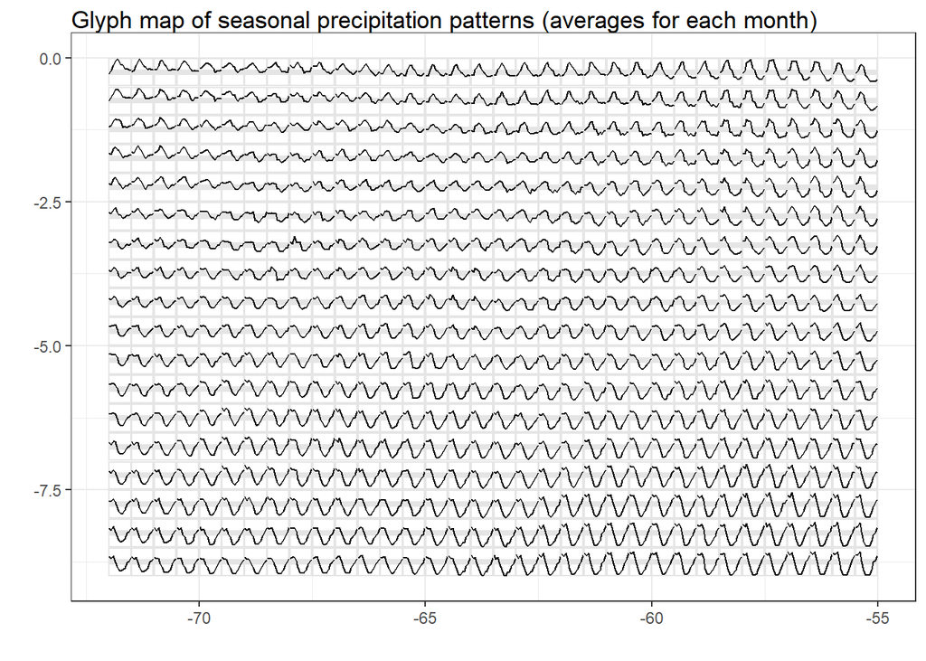

The above figure is a glyph-map of seasonal precipitation patterns (averages for each month) in the Central Amazon Basin. The grey reference lines show the mid-range for easier comparison of the patterns. We see differences in the seasonal patterns across the map. In the upper left for example, the seasonal patterns stay above mid-range while on the bottom-left they have values clearly towards the low end of the range. Also some areas have multimodal patterns. The patterns differ in range and month of maximum and minimun precipitation.

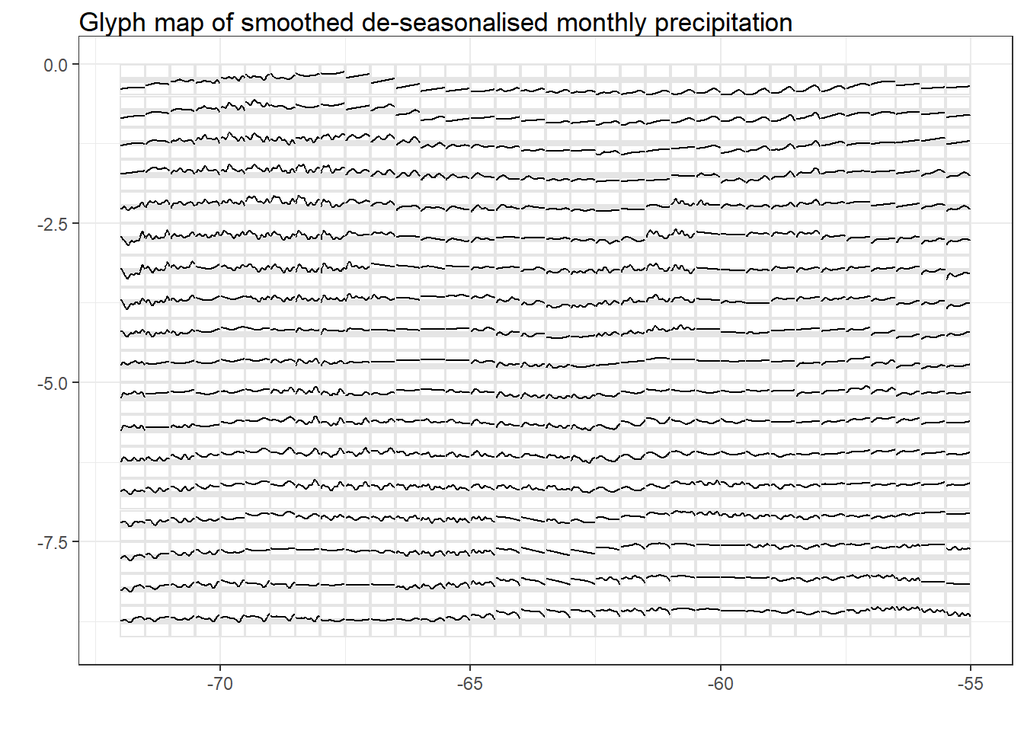

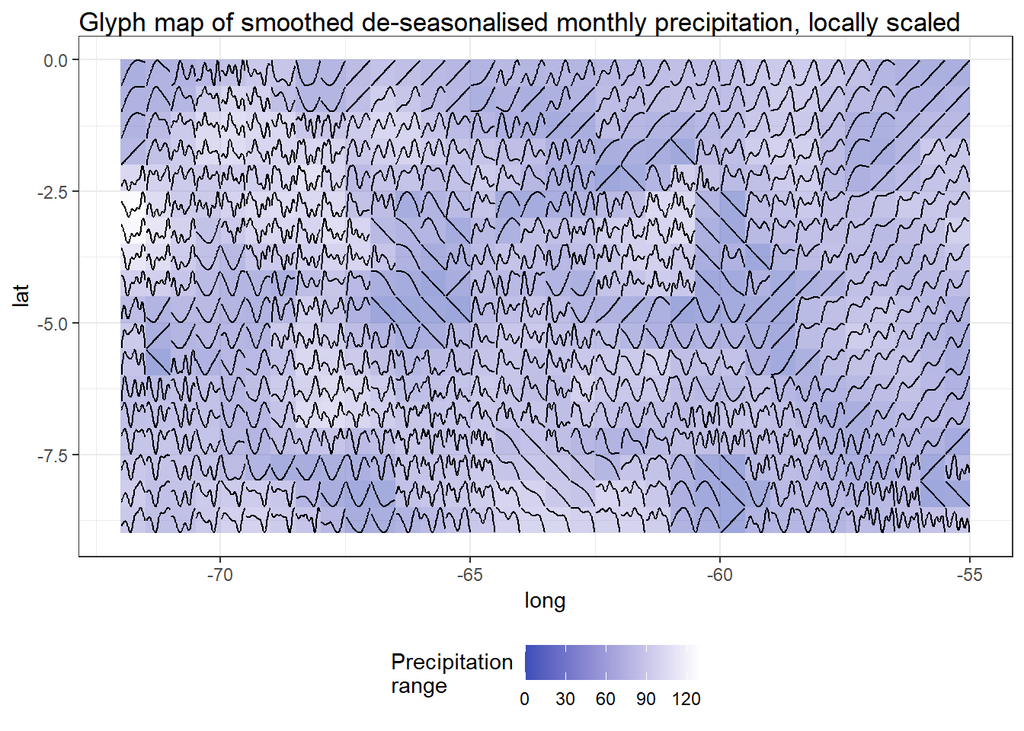

Now we inspect the glyph-map with deseasonalised locally scaled values. This form of scaling emphasizes the individual shapes. Because of the applied scaling, big patterns may be just be tiny effects. Therefore colors are added according to range. Areas with lighter colour have larger ranges than darker areas. The areas with steep linear increases and decreases have smaller ranger than or example the areas below -2.5 latitude in the left.